# Lab 4: Statistics

# 6 Creating a bar plot

We need to get to know our data better. What is the distribution of life expectancy. What about urbanization? We can create bar plots and then histograms.

Let’s create a frequency table.

```r
#Step1: Rounding the values
merged_data2$life_exp_mean_rounded<-round(merged_data2$life_exp_mean, 0)
merged_data2$urb_mean_rounded<-round(merged_data2$urb_mean, 0)
head(merged_data2, n=5)
```

| Code | life_exp_mean | urb_mean | life_exp_mean_rounded | urb_mean_rounded |
| --- | --- | --- | --- | --- |
| ABW | 70.25972 | 48.05939 | 70 | 48 |
| AFG | 45.38333 | 18.61175 | 45 | 19 |
| AGO | 45.08466 | 37.53970 | 45 | 38 |
| ALB | 68.28611 | 40.44416 | 68 | 40 |
| AND | 77.04861 | 87.04302 | 77 | 87 |

```r
#Step2: Creating a frequency table
freq_table<-table(merged_data2$life_exp_mean_rounded)
freq_table
```

```
38 43 44 45 46 47 48 49 50 51 52 53 54 55 56 57 58 59 60 61 62 63 64 65 66 67
 1  2  3  4  4  5  5  2  2  4 11  6  5  6  4  5  6  6 10 10  6  6 12 11  5 11
68 69 70 71 72 73 74 75 77
 9 11 12 12  4  4  1  6  3
```

```r
#Step3: Turning the table into a dataframe
freq_table<-data.frame(freq_table)
```

```r
#Step4: Inspecting the names
#names(freq_table)
names(urbanization_df)
```

```
[1] "Entity"
[2] "Code"
[3] "Year"
[4] "Urban.population....of.total.population."
```

```r
#Step5:Identifying how to extract the variable names
names(freq_table)
```

```
[1] "Var1" "Freq"
```

```r
#Step6: Providing more intuitive names
names(freq_table)[1]<-"life_exp_mean_rounded"
names(freq_table)[2]<-"frequency"
names(freq_table)
```

```
[1] "life_exp_mean_rounded" "frequency"
```

```r
#Step7: Inspecting variable types
str(freq_table)
```

```
'data.frame':   35 obs. of  2 variables:
 $ life_exp_mean_rounded: Factor w/ 35 levels "38","43","44",..: 1 2 3 4 5 6 7 8 9 10 ...
 $ frequency            : int  1 2 3 4 4 5 5 2 2 4 ...
```

```r
#Step8: Turning factor variables into numeric
freq_table$life_exp_mean_rounded<-as.numeric(as.character(freq_table$life_exp_mean_rounded))
str(freq_table)
```

```
'data.frame':   35 obs. of  2 variables:
 $ life_exp_mean_rounded: num  38 43 44 45 46 47 48 49 50 51 ...
 $ frequency            : int  1 2 3 4 4 5 5 2 2 4 ...
```

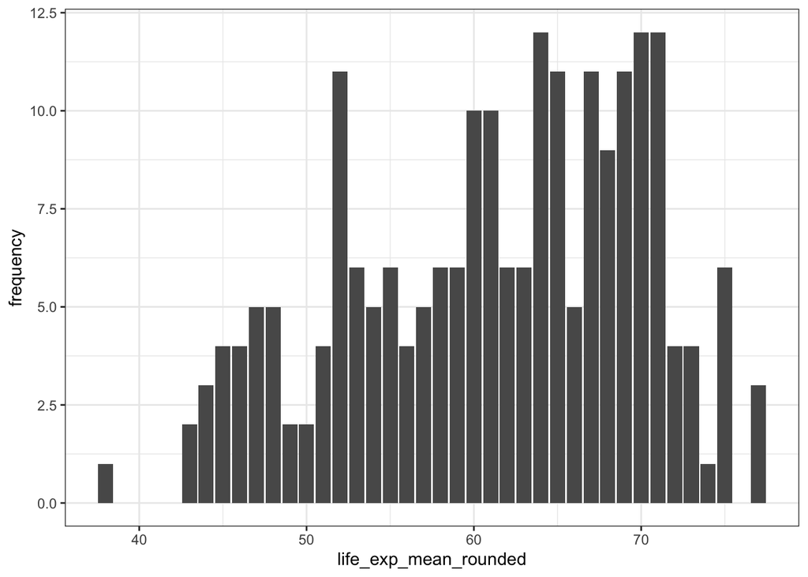

```r
library(ggplot2)
#Step9: Creating the barplot
fig5<-ggplot(data = freq_table, aes(x=life_exp_mean_rounded, y=frequency))+
  geom_bar(stat="identity")+
  theme_bw()

fig5
```

You can obtain a similar graph by using the `geom_histogram` option in ggplot. You will of course have to use some options.

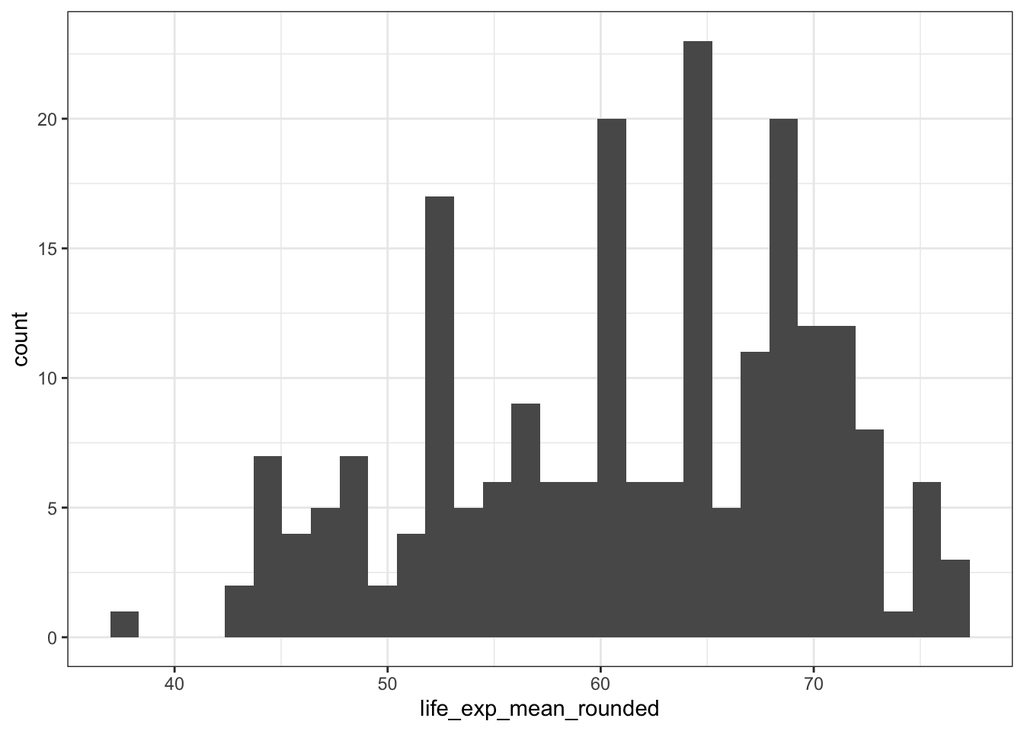

```r
fig5_b<-ggplot(data = merged_data2, aes(x=life_exp_mean_rounded))+
  geom_histogram()+
  theme_bw()
fig5_b
```

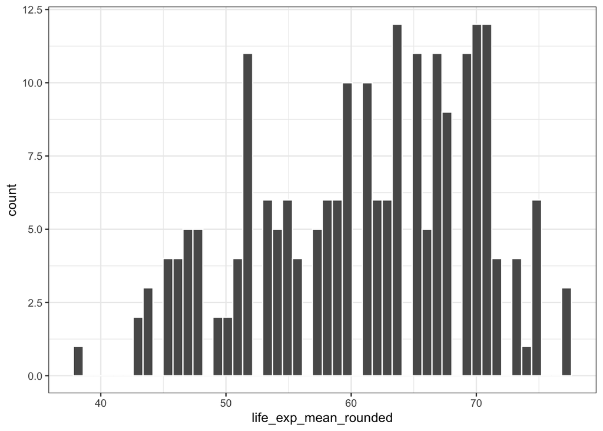

```r
fig5_b<-ggplot(data = merged_data2, aes(x=life_exp_mean_rounded))+
  geom_histogram(bins = 50, col="white")+
  theme_bw()
fig5_b
```

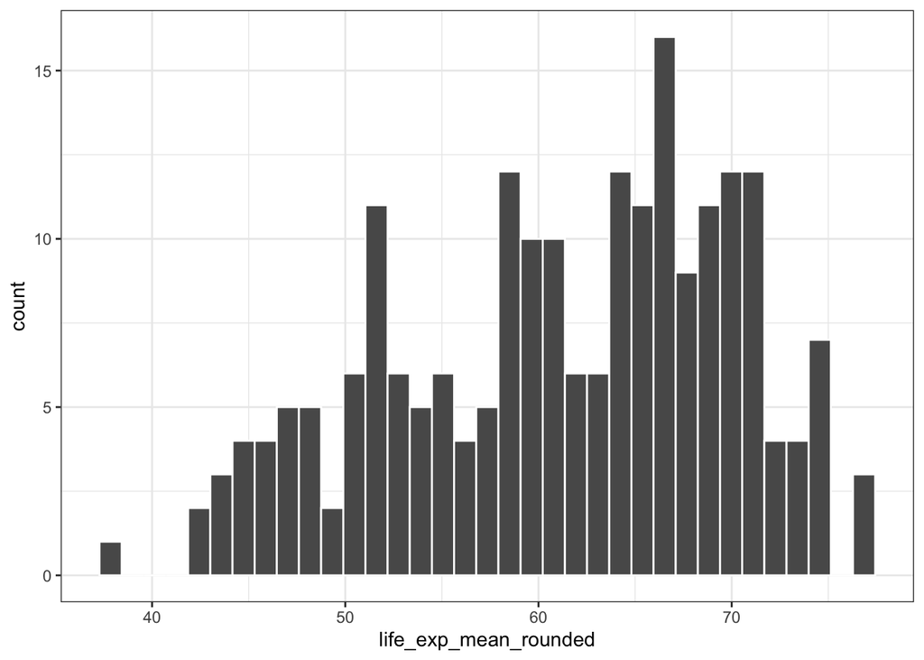

```r
fig5_b<-ggplot(data = merged_data2, aes(x=life_exp_mean_rounded))+
  geom_histogram(bins = 35, col="white")+
  theme_bw()
fig5_b
```

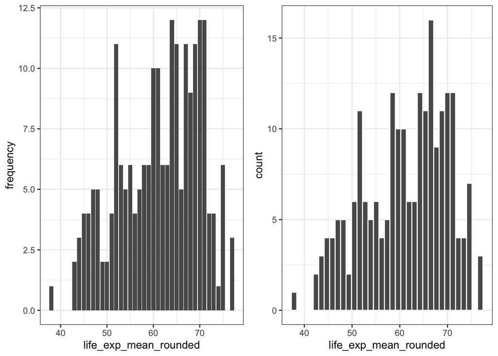

```r
library(gridExtra)
grid.arrange(fig5, fig5_b, ncol=2)
```

## 6.1 Calculating the mean

We already know how to calculate the mean for our dataset. This is 61.243 which is obtained by typing `mean(merged_data2$life_exp_mean_rounded)`

Let us put it in our graph.

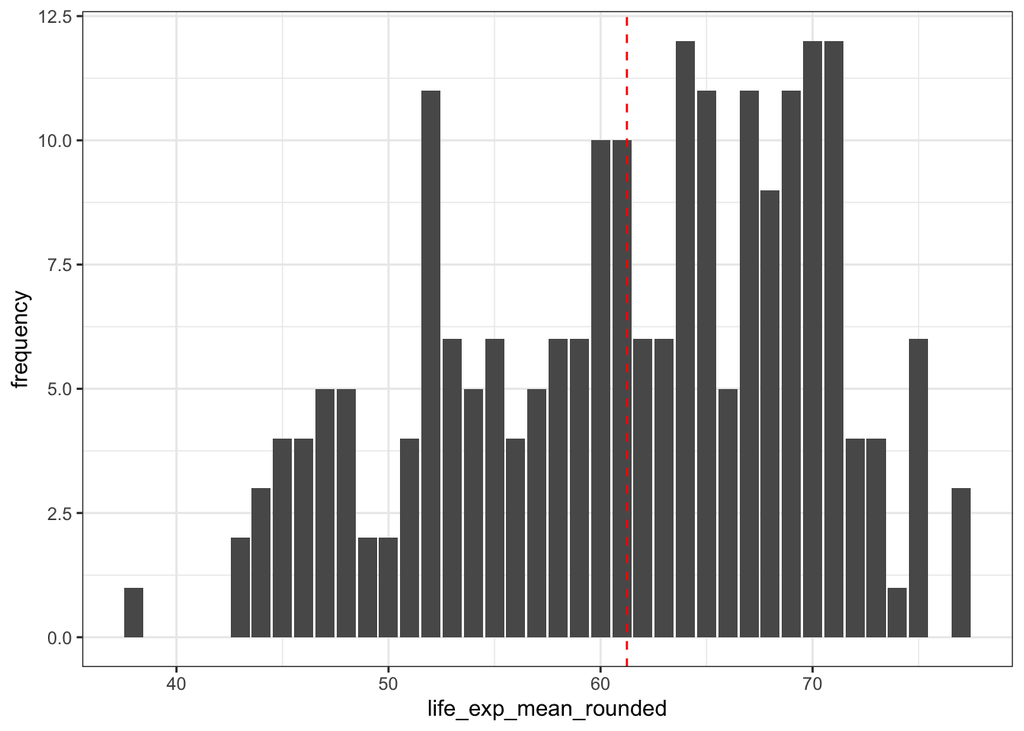

```r
mean_life_expectancy<-mean(merged_data2$life_exp_mean_rounded)
fig6<-ggplot(data = freq_table, aes(x=life_exp_mean_rounded, y=frequency))+
  geom_bar(stat="identity")+
  theme_bw()+
  geom_vline(xintercept=mean_life_expectancy, linetype='dashed', col = 'red')

fig6
```

## 6.2 Adding the mean to the graph

Let us add some some text to indicate that the line is the mean life expectancy in our dataset. The way to do this is by using `annotate`.

Here is how we can do that.

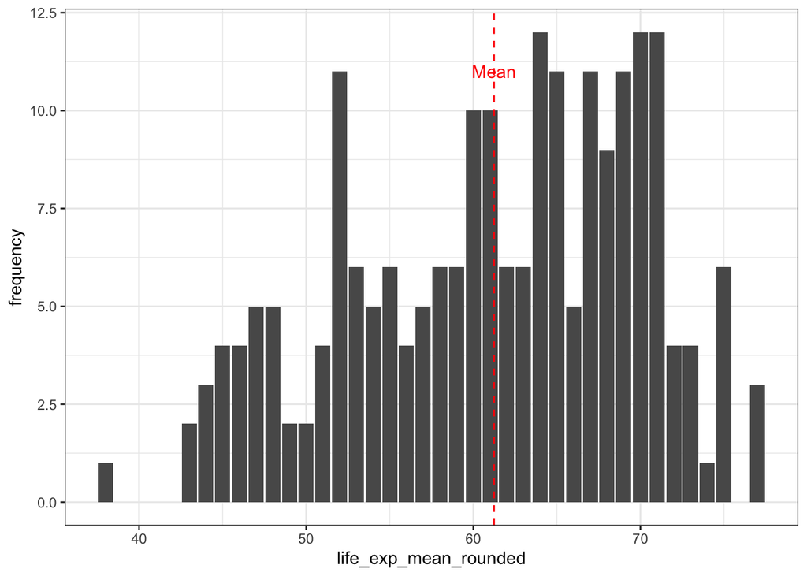

```r
text_to_add<-"Mean"
y_coord<-11
x_coord<-mean((merged_data2$life_exp_mean_rounded))

mean_life_expectancy<-mean((merged_data2$life_exp_mean_rounded))
fig6<-ggplot(data = freq_table, aes(x=life_exp_mean_rounded, y=frequency))+
  geom_bar(stat="identity")+
  theme_bw()+
  geom_vline(xintercept=mean_life_expectancy, linetype='dashed', col = 'red')+
  annotate(geom="text",
           x=x_coord,
           y=y_coord,
           label=text_to_add,
              color="red")

fig6
```

Maybe we want to move the text a bit further to the left. We can subtract 2 from the x_coord.

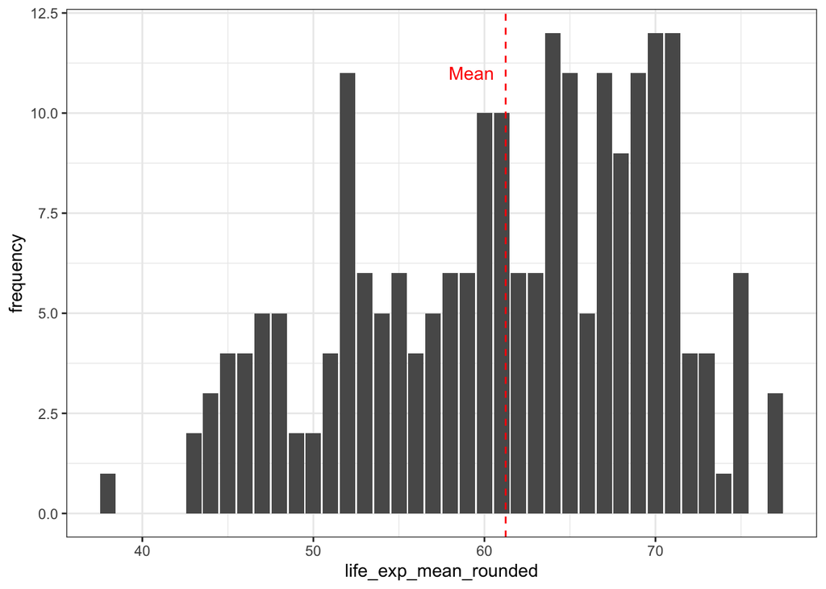

```r
text_to_add<-"Mean"
y_coord<-11
x_coord<-mean((merged_data2$life_exp_mean_rounded))-2

mean_life_expectancy<-mean((merged_data2$life_exp_mean_rounded))
fig6<-ggplot(data = freq_table, aes(x=life_exp_mean_rounded, y=frequency))+
  geom_bar(stat="identity")+
  theme_bw()+
  geom_vline(xintercept=mean_life_expectancy, linetype='dashed', col = 'red')+
  annotate(geom="text",
           x=x_coord,
           y=y_coord,
           label=text_to_add,
              color="red")

fig6
```

# 7 Creating a line plot

An important question is understanding how life expectancy might have evolved over time. Let us go back to the original dataset before calculating the averages.

```r
head(life_expectancy_df, n=6)
```

|  | Entity | Code | Year | Life.expectancy.at.birth..historical. |
| --- | --- | --- | --- | --- |
| 1 | Afghanistan | AFG | 1950 | 27.7 |
| 2 | Afghanistan | AFG | 1951 | 28.0 |
| 3 | Afghanistan | AFG | 1952 | 28.4 |
| 4 | Afghanistan | AFG | 1953 | 28.9 |
| 5 | Afghanistan | AFG | 1954 | 29.2 |
| 6 | Afghanistan | AFG | 1955 | 29.9 |

```r
#Renaming variable
names(life_expectancy_df)[4]<-"life_exp_yearly"
head(life_expectancy_df, n=6)
```

|  | Entity | Code | Year | life_exp_yearly |
| --- | --- | --- | --- | --- |
| 1 | Afghanistan | AFG | 1950 | 27.7 |
| 2 | Afghanistan | AFG | 1951 | 28.0 |
| 3 | Afghanistan | AFG | 1952 | 28.4 |
| 4 | Afghanistan | AFG | 1953 | 28.9 |
| 5 | Afghanistan | AFG | 1954 | 29.2 |
| 6 | Afghanistan | AFG | 1955 | 29.9 |

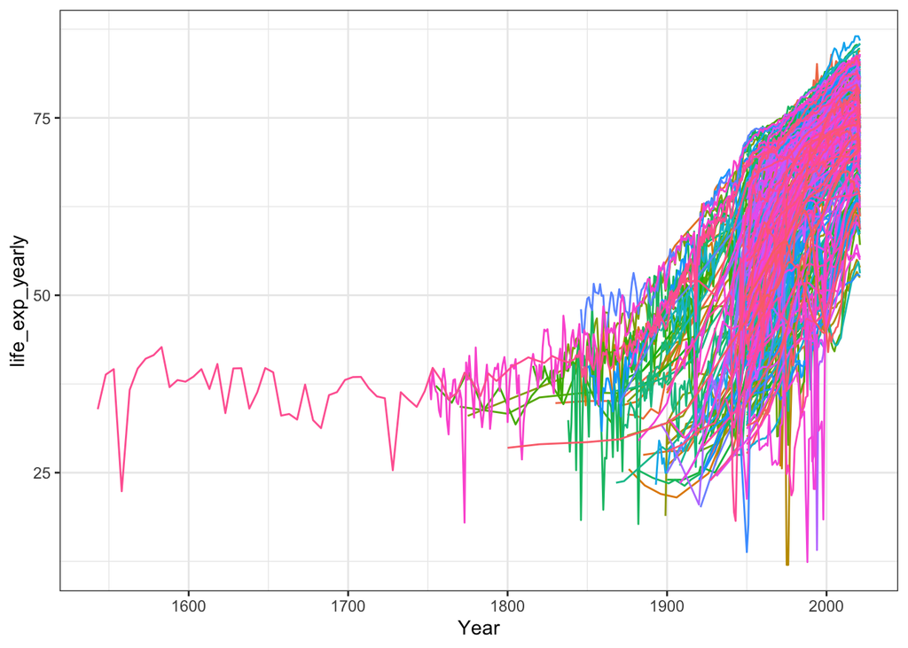

```r
fig7<-ggplot(data = life_expectancy_df, aes(x = Year, y = life_exp_yearly))+
  geom_line(aes(color = Entity))+
  theme_bw()+
  guides(color = "none")
fig7
```

Unfortunately, we cannot make out much out of this graph, as we have way too many countries. It probably makes sense to focus on 1-2 coutries. Let’s take the US and the UK as an example.

## 7.1 Subsetting the sample to fewer countries

```r
countries_of_interest<-c("United States", "United Kingdom")
df_us_uk<-subset(life_expectancy_df, Entity %in% countries_of_interest)
head(df_us_uk, n=10)
```

|  | Entity | Code | Year | life_exp_yearly |
| --- | --- | --- | --- | --- |
| 19059 | United Kingdom | GBR | 1543 | 33.94 |
| 19060 | United Kingdom | GBR | 1548 | 38.82 |
| 19061 | United Kingdom | GBR | 1553 | 39.59 |
| 19062 | United Kingdom | GBR | 1558 | 22.38 |
| 19063 | United Kingdom | GBR | 1563 | 36.66 |
| 19064 | United Kingdom | GBR | 1568 | 39.67 |
| 19065 | United Kingdom | GBR | 1573 | 41.06 |
| 19066 | United Kingdom | GBR | 1578 | 41.56 |
| 19067 | United Kingdom | GBR | 1583 | 42.70 |
| 19068 | United Kingdom | GBR | 1588 | 37.05 |

Let us now plot life expectancy only for the US and the UK.

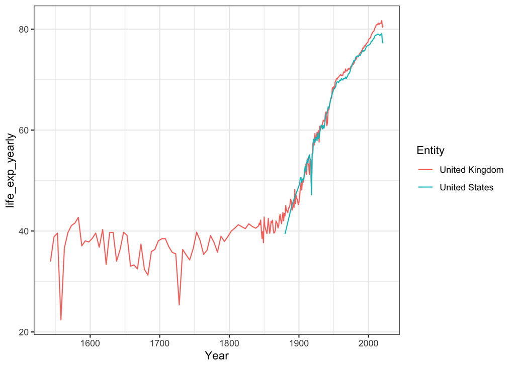

```r
fig8<-ggplot(data = df_us_uk, aes(x = Year, y = life_exp_yearly))+
  geom_line(aes(color = Entity))+
  theme_bw()

fig8
```

## 7.2 Subsetting the sample to fewer years

It is kind of cool that in the UK, there is data that goes so far back. For comparison purposes, it might be a good idea to restrict our sample to the period after 1900.

```r
df_us_uk_after1900<-subset(df_us_uk, Year>1900)
head(df_us_uk_after1900, n=10)
```

|  | Entity | Code | Year | life_exp_yearly |
| --- | --- | --- | --- | --- |
| 19178 | United Kingdom | GBR | 1901 | 46.93 |
| 19179 | United Kingdom | GBR | 1902 | 48.36 |
| 19180 | United Kingdom | GBR | 1903 | 49.54 |
| 19181 | United Kingdom | GBR | 1904 | 48.14 |
| 19182 | United Kingdom | GBR | 1905 | 49.92 |
| 19183 | United Kingdom | GBR | 1906 | 49.60 |
| 19184 | United Kingdom | GBR | 1907 | 50.56 |
| 19185 | United Kingdom | GBR | 1908 | 51.02 |
| 19186 | United Kingdom | GBR | 1909 | 51.67 |
| 19187 | United Kingdom | GBR | 1910 | 53.26 |

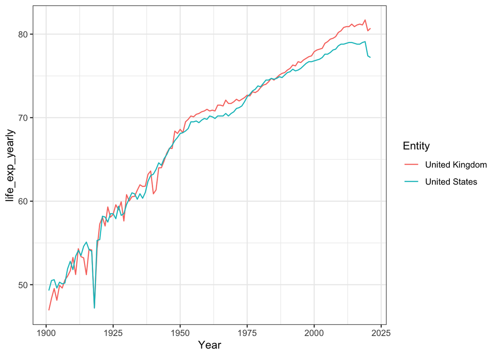

```r
fig9<-ggplot(data = df_us_uk_after1900, aes(x = Year, y = life_exp_yearly))+
  geom_line(aes(color = Entity))+
  theme_bw()

fig9
```

Let’s color the two countries in red and blue so that the difference is clearer.

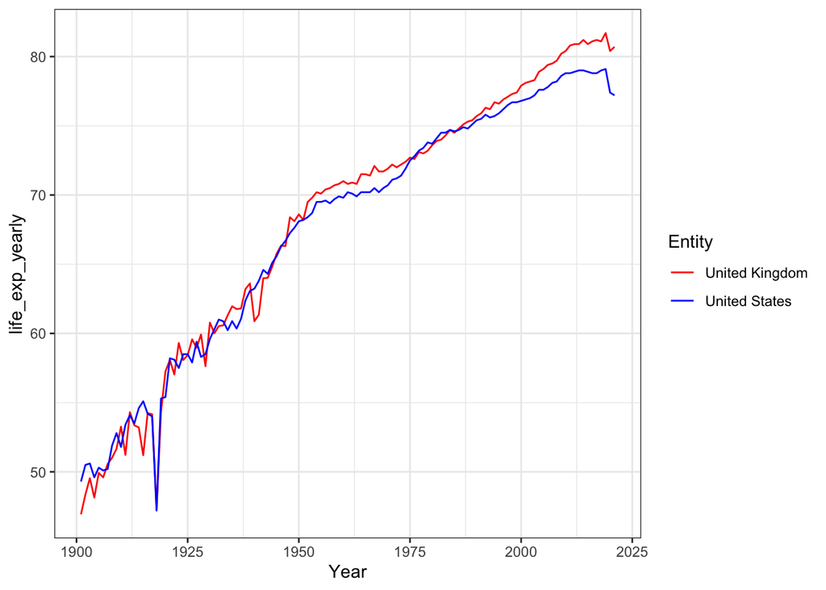

```r
fig9<-ggplot(data = df_us_uk_after1900, aes(x = Year, y = life_exp_yearly))+
  geom_line(aes(color = Entity))+
  theme_bw()+
  scale_color_manual(values=c('Red','Blue'))

fig9
```

What is the year with the lowest life expectancy for the US?

```r
#Creating a new df with the US
df_us_after1900<-subset(df_us_uk_after1900, Entity=="United States")
df_us_after1900$Year[df_us_after1900$life_exp_yearly==min(df_us_after1900$life_exp_yearly)]
```

```
[1] 1918
```

What is the year with the second lowest life expectancy for the US?

```r
#Arranging and creating a new dataframe
df <- df_us_after1900 %>% arrange(life_exp_yearly)
#Selecting the second lowest
second_highest_life_expectancy <- df$life_exp_yearly[2]
#Selecting the year with the second lowest
df$Year[df$life_exp_yearly==second_highest_life_expectancy]
```

```
[1] 1901
```

What is the year with the lowest life expectancy for the UK?

```r
#Creating a new df with the UK
df_uk_after1900<-subset(df_us_uk_after1900, Entity=="United Kingdom")
df_uk_after1900$Year[df_uk_after1900$life_exp_yearly==min(df_uk_after1900$life_exp_yearly)]
```

```
[1] 1901
```

Great! We have gone over a variety of graphs in ggplot including points, barplots, and time lines. You are now in a very good position to do some basic data analysis in R.